# Altura Máxima Potencial da Vegetação Nativa

## Carregando pacotes utilizados.

```r
require(raster)
```

```r
require(dplyr)
```

```r
require(rgdal)
```

```r
require(repmis)
```

```r
require(randomForest)
```

```r
require(caret)
```

## Carregando dados utilizados.

Previamente a análise de dados foi feito um grid de pontos regulares com espaçamento de 5.000 x 5.000m sobre as camadas de variáveis ambientais. Todas as camadas ambientais puderam ser obtidas atraves de plataformas Open Source como o Google Earth Engine e a NASA Search Engine para dados GEDI.

### Download de dados.

Os pontos de amostras podem ser obtidos a partir do link para o google drive abaixo. https://drive.google.com/drive/folders/1QanoZOvPIz2DayJjVKYLTdrzBkScVAOY?usp=sharing OBS: Os pontos de amostras são um arquivo vetor em formato shapefile, portanto para a analise todos documentos contidos dentro do drive devem ser baixados para acompanhar as analises realizadas.

```r
Amostras <- shapefile('amostras.shp')
Amostras <- Amostras@data
```

## Limpeza e integridade dos pontos selecionados.

```r
Amostras_filtradas <- subset(Amostras, !is.na(rh100))
Amostras_filtradas <- subset(Amostras_filtradas, mapbiomas. == 3 | mapbiomas. == 4 |mapbiomas. == 12)
```

### Convenção de nomeclaturas para variáveis.

As variaveis seguem as nomeclaturas a seguir. mapbiomas: Classes de formação de florestas naturais filtradas nos passos anterior, 3 classes presentes (formação floresta, campestre e savânica); count: Número de pulsos emitidos à superficie terrestre pelo sistema LiDar; rh100: Altura relativa de copa acima do solo; tempMA: Temperatura média anual; precMA: Precipitação média anual; NAnuvens: Número de dias sem cobertura de nuvens; Inf100: Número de meses com precipitação inferior a 100 milímetros; mde: Modelo digital de elevação; decliv: Declividade

```r
names(Amostras_filtradas) <- c('mapbiomas', 'count', 'rh100', 'tempMA', 'precMA',
                'NAnuvens', 'Inf100', 'mde', 'decliv')
```

### Correlacionando variáveis.

Para determinarmos quais inputs serao selecionados para treinamento do modelo Random Forest. De acordo com a correlçao, somente o modelo digital de elevação apresenta influencia nula sobre a altura relativa, corr(0.03). Portanto esta será removida dos calculos. A varivel de precipitação média anual e numero de meses com precipitação inferior a 100mm apresentaram baixa correlação, poderemos explorar isso mais a frente.

```r
corTemp <- cor(Amostras_filtradas$tempMA, Amostras_filtradas$rh100)
corPrec <- cor(Amostras_filtradas$precMA, Amostras_filtradas$rh100)
corDec <- cor(Amostras_filtradas$decliv, Amostras_filtradas$rh100)
corMde <- cor(Amostras_filtradas$mde, Amostras_filtradas$rh100)
corNanuvens <- cor(Amostras_filtradas$NAnuvens, Amostras_filtradas$rh100)
corInf100 <- cor(Amostras_filtradas$Inf100, Amostras_filtradas$rh100)
```

## Cálculos de Fronteira de eficiencia.

```r
Altura_potencial <- data.frame()
```

### Range de amostras para variavel de temperatura média anual.

Seleção de 20 amostras dentro dos valores maximos (25) e minimos(12.5) apresentados pela variavel temperatura média anual.

```r
Range_amostras <- range(Amostras_filtradas$tempMA)
Quantidade_de_amostras <- 20
Range_amostras <- seq(Range_amostras[1]-0.1, Range_amostras[2], length.out = Quantidade_de_amostras)
```

### Cálculo de máximos locais para fronteira de eficiência da temperatura média anual.

```r
Front_eficiencia <- data.frame()
for(b in seq(1, Quantidade_de_amostras-1, 1)){
    tempB <- Amostras_filtradas[Amostras_filtradas$tempMA > Range_amostras[b] & Amostras_filtradas$tempMA <= Range_amostras[b+1],]
    tempB
    tempB <- arrange(tempB, rh100)
    Front_eficiencia <- rbind(Front_eficiencia, tail(tempB, 1))
}
```

### Plot simples dos dados calculados para a temperatura média anual.

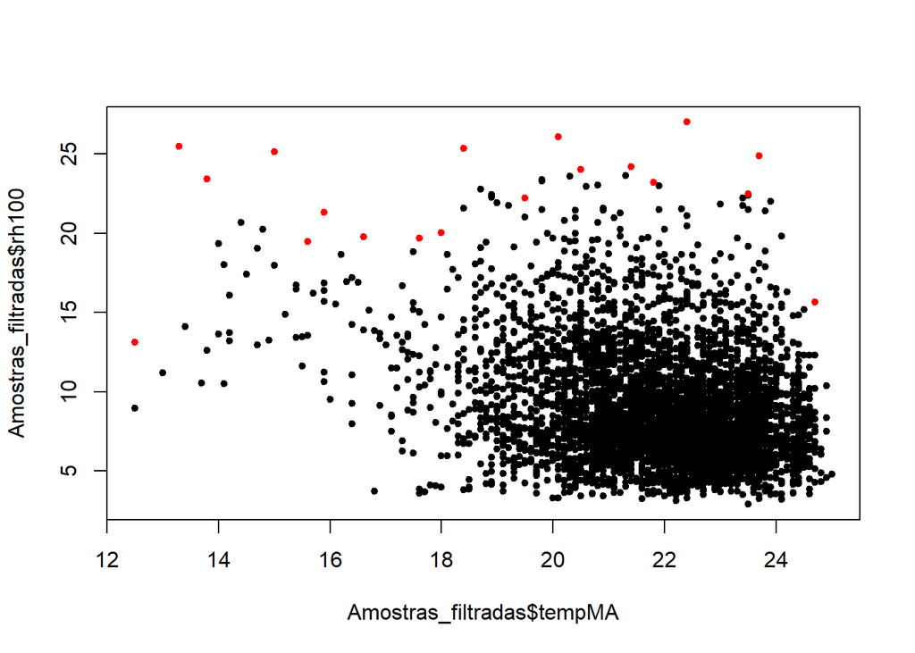

```r
plot(Amostras_filtradas$tempMA, Amostras_filtradas$rh100, pch = 20)
points(Front_eficiencia$tempMA, Front_eficiencia$rh100, pch = 20, col = 'red')
```

Pelo grafico podemos observar a tendencia de permanencia da media de valores da altura relativa de acordo com a variação de temperatura média anual. Mesmo tendo certa correlação entre variáveis, a temperatura média anual será descartada para treinamento do modelo da altura máxima potencial.

### Range de amostras para variavel de precipitação média anual.

Seleção de 20 amostras dentro dos valores maximos (2173) e minimos(706) apresentados pela variavel precipitação média anual.

```r
Range_amostras <- range(Amostras_filtradas$precMA)
Quantidade_de_amostras <- 20
Range_amostras <- seq(Range_amostras[1]-0.1, Range_amostras[2], length.out = Quantidade_de_amostras)
```

### Cálculo de máximos locais para fronteira de eficiência da precipitação média anual.

```r
Front_eficiencia <- data.frame()
for(b in seq(1, Quantidade_de_amostras-1, 1)){
    tempB <- Amostras_filtradas[Amostras_filtradas$precMA > Range_amostras[b] & Amostras_filtradas$precMA <= Range_amostras[b+1],]
    tempB
    tempB <- arrange(tempB, rh100)
    Front_eficiencia <- rbind(Front_eficiencia, tail(tempB, 1))
}
Altura_potencial <- rbind(Altura_potencial, Front_eficiencia)
```

### Plot simples dos dados calculados para a precipitação média anual.

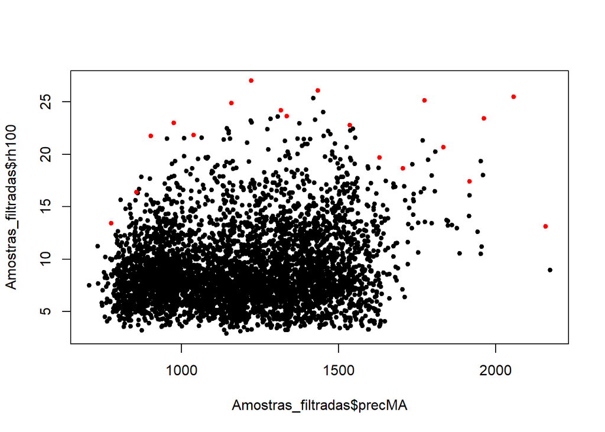

```r
plot(Amostras_filtradas$precMA, Amostras_filtradas$rh100, pch = 20)
points(Front_eficiencia$precMA, Front_eficiencia$rh100, pch = 20, col = 'red')
```

### Range de amostras para variavel de numeros de meses com precipitação inferior a 100mm.

Seleção de 20 amostras dentro dos valores maximos (10.4) e minimos(5.2) apresentados pela variavel numero de meses com precipitação inferior a 100mm.

```r
Range_amostras <- range(Amostras_filtradas$Inf100)
Quantidade_de_amostras <- 20
Range_amostras <- seq(Range_amostras[1]-0.1, Range_amostras[2], length.out = Quantidade_de_amostras)
```

### Cálculo de máximos locais para fronteira de eficiência do numero de meses com precipitação inferior a 100mm.

```r
Front_eficiencia <- data.frame()
for(b in seq(1, Quantidade_de_amostras-1, 1)){
    tempB <- Amostras_filtradas[Amostras_filtradas$Inf100 > Range_amostras[b] & Amostras_filtradas$Inf100 <= Range_amostras[b+1],]
    tempB
    tempB <- arrange(tempB, rh100)
    Front_eficiencia <- rbind(Front_eficiencia, tail(tempB, 1))
}
Altura_potencial <- rbind(Altura_potencial, Front_eficiencia)
```

### Plot simples dos dados calculados para o numero de meses com precipitação inferior a 100mm.

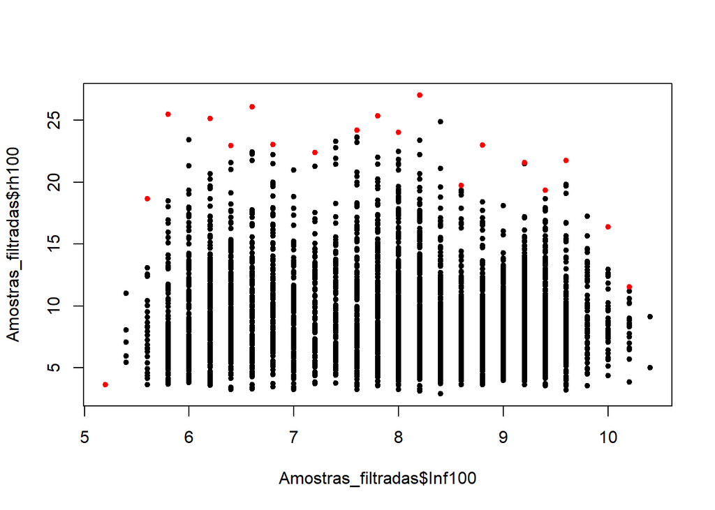

```r
plot(Amostras_filtradas$Inf100, Amostras_filtradas$rh100, pch = 20)
points(Front_eficiencia$Inf100, Front_eficiencia$rh100, pch = 20, col = 'red')
```

### Range de amostras para variavel de declividade.

Seleção de 20 amostras dentro dos valores maximos (47.9) e minimos(0) apresentados pela variavel declividade.

```r
Range_amostras <- range(Amostras_filtradas$decliv)
Quantidade_de_amostras <- 20
Range_amostras <- seq(Range_amostras[1]-0.1, Range_amostras[2], length.out = Quantidade_de_amostras)
```

```r
Front_eficiencia <- data.frame()
for(b in seq(1, Quantidade_de_amostras-1, 1)){
    tempB <- Amostras_filtradas[Amostras_filtradas$decliv > Range_amostras[b] & Amostras_filtradas$decliv <= Range_amostras[b+1],]
    tempB
    tempB <- arrange(tempB, rh100)
    Front_eficiencia <- rbind(Front_eficiencia, tail(tempB, 1))
}
Altura_potencial <- rbind(Altura_potencial, Front_eficiencia)
```

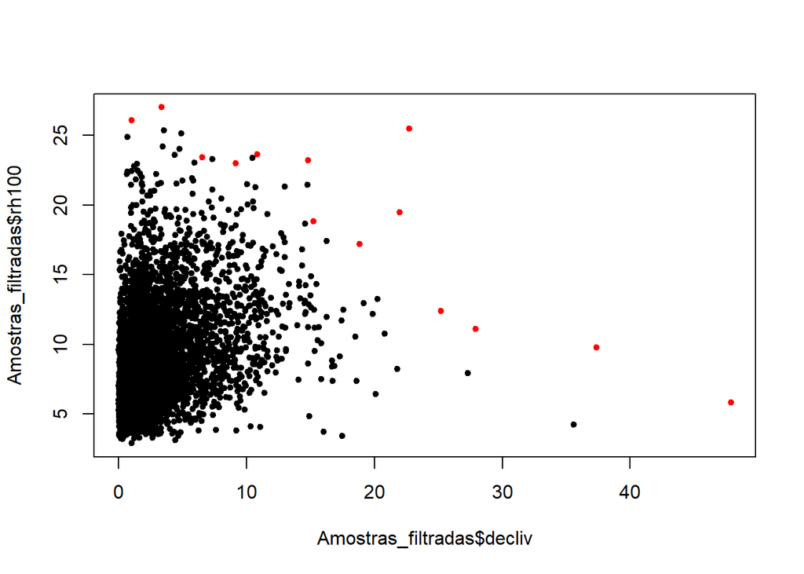

```r
plot(Amostras_filtradas$decliv, Amostras_filtradas$rh100, pch = 20)
points(Front_eficiencia$decliv, Front_eficiencia$rh100, pch = 20, col = 'red')
```

### Range de amostras para variavel de número de dias sem cobertura de núvens.

Seleção de 20 amostras dentro dos valores maximos (226) e minimos(15) apresentados pela variavel numero de dias sem cobertura de nuvens.

```r
Range_amostras <- range(Amostras_filtradas$NAnuvens)
Quantidade_de_amostras <- 20
Range_amostras <- seq(Range_amostras[1]-0.1, Range_amostras[2], length.out = Quantidade_de_amostras)
```

### Cálculo de máximos locais para fronteira de eficiência do número de dias sem cobertura de núvens.

```r
Front_eficiencia <- data.frame()
for(b in seq(1, Quantidade_de_amostras-1, 1)){
    tempB <- Amostras_filtradas[Amostras_filtradas$NAnuvens > Range_amostras[b] & Amostras_filtradas$NAnuvens <= Range_amostras[b+1],]
    tempB
    tempB <- arrange(tempB, rh100)
    Front_eficiencia <- rbind(Front_eficiencia, tail(tempB, 1))
}
Altura_potencial <- rbind(Altura_potencial, Front_eficiencia)
```

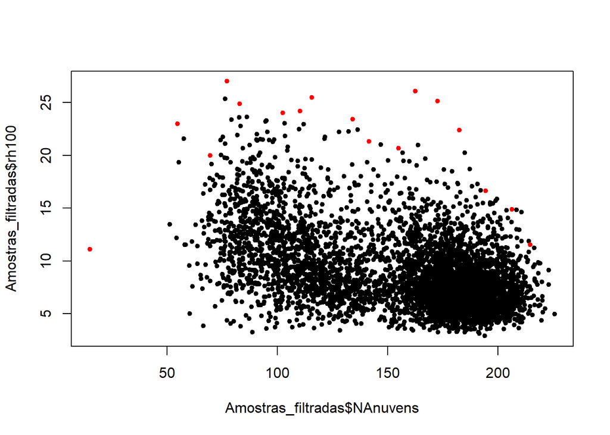

```r
plot(Amostras_filtradas$NAnuvens, Amostras_filtradas$rh100, pch = 20)
points(Front_eficiencia$NAnuvens, Front_eficiencia$rh100, pch = 20, col = 'red')
```

## Modelagem por Machine Learning Random Forest

Seleção dos inputs do modelo que apresentarem melhores correlações com a variavel rh100 (). E seleção do output de predição do modelo, no caso, esperamos estimar a Altura Relativa dos povoamentos florestais.

```r
input <- Altura_potencial %>%
    select(-mapbiomas) %>%
    select(-mde) %>%
    select(-tempMA) %>%
    select(-count) %>%
    select(-rh100)

output <- Altura_potencial %>% select(rh100)
```

### Treinamento do modelo Random Forest

O modelo será submetido a validação cruzada de 5K folds para melhor acurácia.

```r
drivers <- cbind(output, input)

folds <- drivers %>%
    row.names() %>%
    groupKFold(k = 5)

group_fit_control <- trainControl(index = folds, method = "cv", number = 5)


rf.altura <- train(rh100 ~ .,
                    data = drivers,
                    method='rf',
                    importance=T,
                    trControl = group_fit_control)

rm(folds, group_fit_control, drivers)
```

### Visualização do modelo treinado

```r
print(rf.altura)
```

```
## Random Forest
##
    ## 69 samples
    ##  4 predictor
    ##
    ## No pre-processing
    ## Resampling: Cross-Validated (5 fold)
    ## Summary of sample sizes: 53, 53, 56, 58, 56
    ## Resampling results across tuning parameters:
    ##
    ##   mtry  RMSE      Rsquared   MAE
    ##   2     3.947821  0.5315087  2.611512
    ##   3     3.992688  0.5247494  2.626906
    ##   4     4.017549  0.5057881  2.644254
    ##
    ## RMSE was used to select the optimal model using the smallest value.
    ## The final value used for the model was mtry = 2.
```

```r
varImp(rf.altura)
```

```
## rf variable importance
##
    ##          Overall
    ## decliv   100.000
    ## precMA    82.571
    ## Inf100     8.802
    ## NAnuvens   0.000
```

### Importação de camadas

Para predição dos valores treinados pelo modelo Random Forest é necessario a importação de camadas raster que representam os valores extraidos no conjunto de dados Amostras.

#### Download de dados.

As camadas utilizadas podem ser obtidos a partir do link para o google drive abaixo. https://drive.google.com/drive/folders/1QanoZOvPIz2DayJjVKYLTdrzBkScVAOY?usp=sharing

### Configurando a camada declividade como referencia

Para os proximos raster apresentarem matrizes de mesma configuração, utilizaremos a camada declividade como referencia.

```r
decliv <- abs(raster('decliv.tif'))
decliv <- setMinMax(decliv)
ref <- abs(decliv)
```

### Configurando demais camadas

```r
NAnuvens <- raster('NAnuvens.tif') %>% crop(ref)
NAnuvens <- abs(NAnuvens)
NAnuvens <- raster(vals=values(NAnuvens),
                        ext=extent(ref),
                        nrows=dim(ref)[1],
                        ncols=dim(ref)[2])
NAnuvens <- setMinMax(NAnuvens)


Inf100 <- raster('Inf100.tif') %>% crop(ref)
Inf100 <- abs(Inf100)
Inf100 <- raster(vals=values(Inf100),
                        ext=extent(ref),
                        nrows=dim(ref)[1],
                        ncols=dim(ref)[2])
Inf100 <- setMinMax(Inf100)


precMA <- raster('precMA.tif') %>% crop(ref)
precMA <- abs(precMA)
precMA <- raster(vals=values(precMA),
                        ext=extent(ref),
                        nrows=dim(ref)[1],
                        ncols=dim(ref)[2])
precMA <- setMinMax(precMA)
```

### Stack de camadas e predição

Com as camadas nas devidas dimensoes, podemos fazer o stack das mesmas para entao utilizar no modelo treinado. O objeto Raster_altura será o produto final desta análise.

```r
layers <- stack(decliv, NAnuvens, Inf100, precMA)
names(layers) <- c("decliv","NAnuvens","Inf100","precMA")

Raster_altura <- predict(layers, rf.altura)
```

### Exportação de camada

Caso queira salvar como .tif

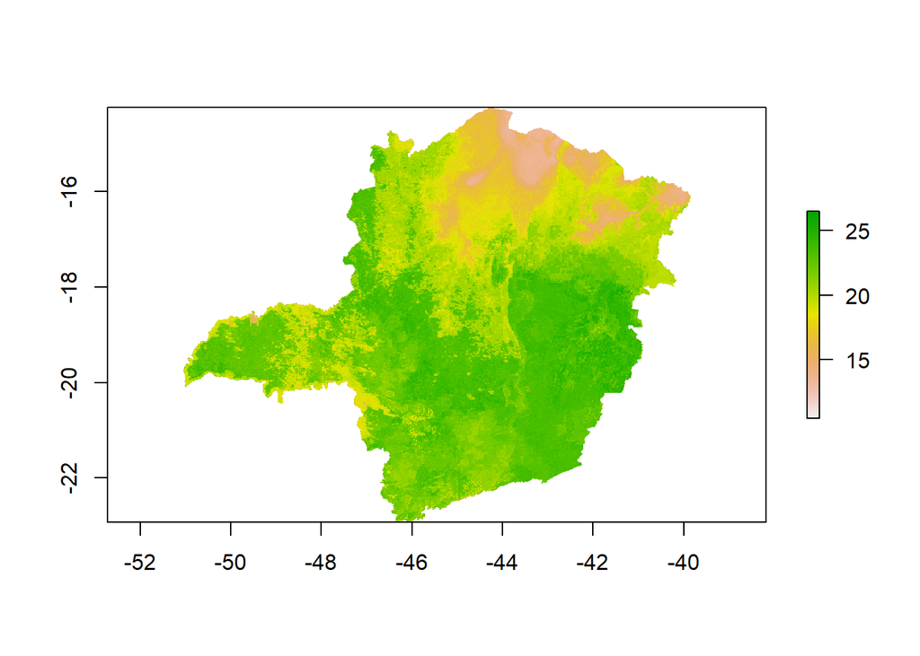

```r
# writeRaster(Raster_altura, 'altura_potencial_M.tif')
plot(Raster_altura)
```